# modelAnalysis

# Load libraries

```r
library(tidyverse)
library(dplyr)
library(patchwork)
library(car)
library(caret)
library(olsrr)
library(glmnet)
```

# Load data

```r
data <- read.csv("data/AmesHousing.csv", header = TRUE, sep = ";")

explanatoryVars <- c("Gr.Liv.Area", "Total.Bsmt.SF", "Garage.Area", "Lot.Area",
                      "Overall.Qual", "Year.Built", "Year.Remod.Add",
                      "Neighborhood", "House.Style")

targetVar <- c("SalePrice")

data <- data[, c(explanatoryVars, targetVar)]
```

## Managing missing values

```r
countNA <- colSums(is.na(data), na.rm = FALSE)
as.data.frame(countNA)
```

```
##                countNA
## Gr.Liv.Area          0
## Total.Bsmt.SF        1
## Garage.Area          1
## Lot.Area             0
## Overall.Qual         0
## Year.Built           0
## Year.Remod.Add       0
## Neighborhood         0
## House.Style          0
## SalePrice            0
```

```r
indexMissingTotal.Bsmt.SF<- which(is.na(data$Total.Bsmt.SF))
indexMissingGarage.Area <- which(is.na(data$Garage.Area))

print(indexMissingGarage.Area)
```

```
## [1] 2237
```

```r
print(indexMissingTotal.Bsmt.SF)
```

```
## [1] 1342
```

```r
data <- drop_na(data)
```

## Split data

```r
set.seed(42)
sampleSize <- floor(0.20*nrow(data))

index <- sample(seq_len(nrow(data)), size = sampleSize)

temp <- data[index,]
train <- data[-index,]

# validation and test

sampleSizeValidation <- floor(0.50*nrow(temp))
indexValidation <- sample(seq_len(nrow(temp)), size=sampleSizeValidation)

validation <- temp[indexValidation,]
test <- temp[-indexValidation, ]

levelsOrderNeighborhood<- levels(as_factor(data[-index,]$Neighborhood))
levelsOrderHouseStyle<- levels(as_factor(data[-index,]$House.Style))
```

# Model creation and analysis

## Full model

```r
modelFull <- lm(SalePrice ~ ., data = train)
```

Plotting: * Residuals vs Fitted (check linearity assumption) * Q-Q residuals (Check normal distribution of Residuals) * Scale-Location (Used to check homoskedasticity) * Residuals vs Leverage (Used to individuate influential outliers)

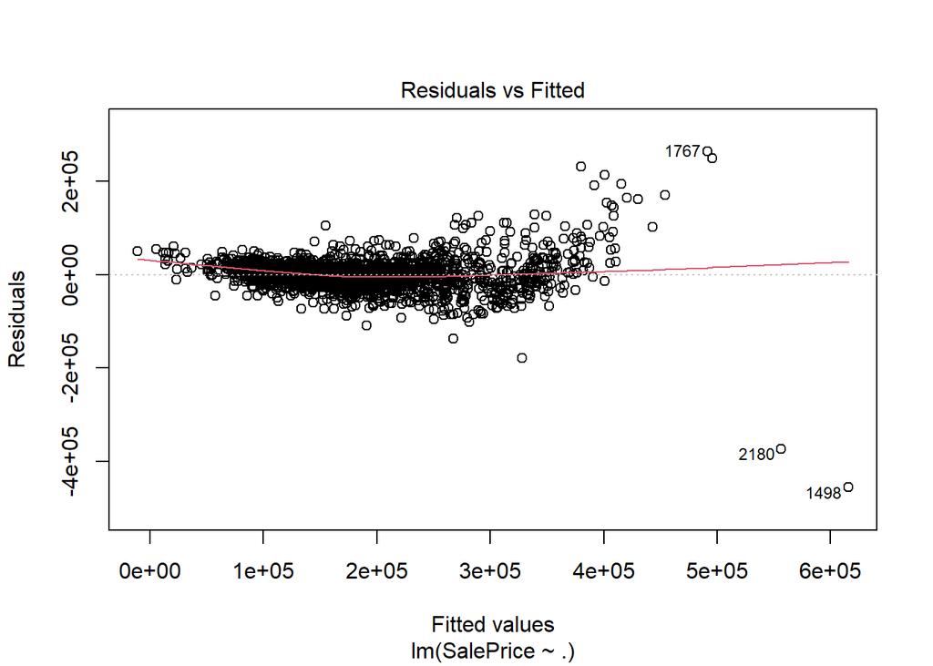

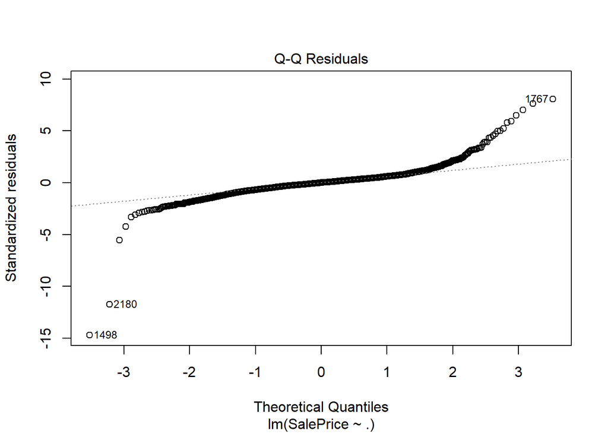

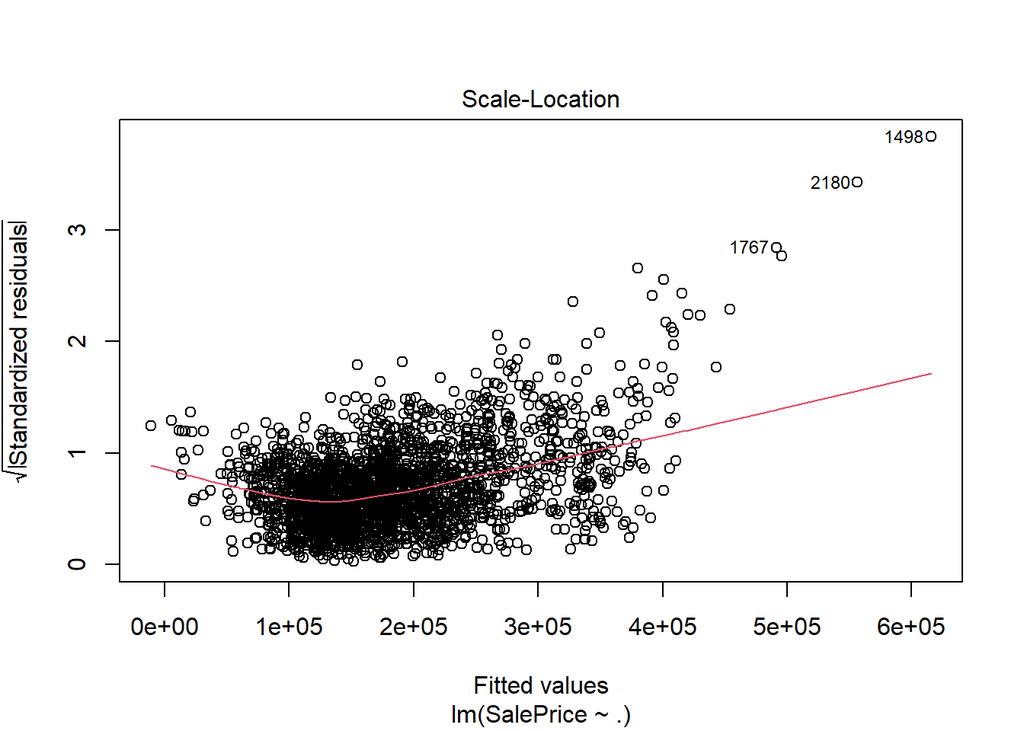

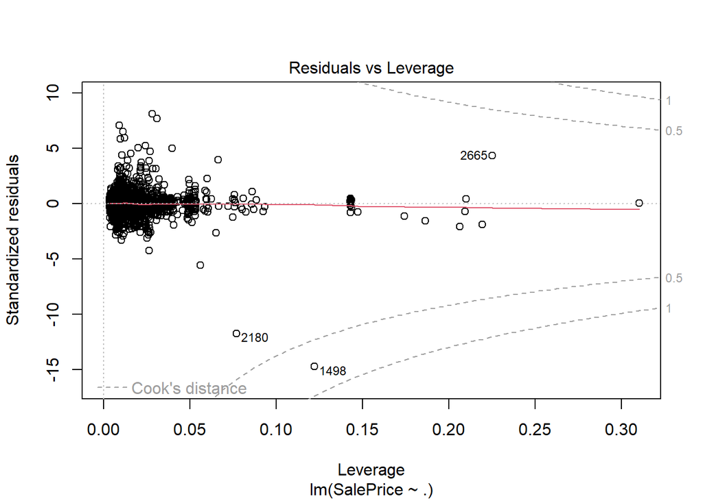

```r
plot(modelFull)
```

- Linearity assumption isn’t satisfied for extreme values of the target variables.
- Residuals are not normally distributed for extreme values
- Homoskedasticity assumption isn’t satisfied
- There are just three influential values at indexes: 2180, 1498, 2665

## Check for multicollinearity

starting with correlation matrix:

```r
source("src/modelAnalysisFunctions.R")
```

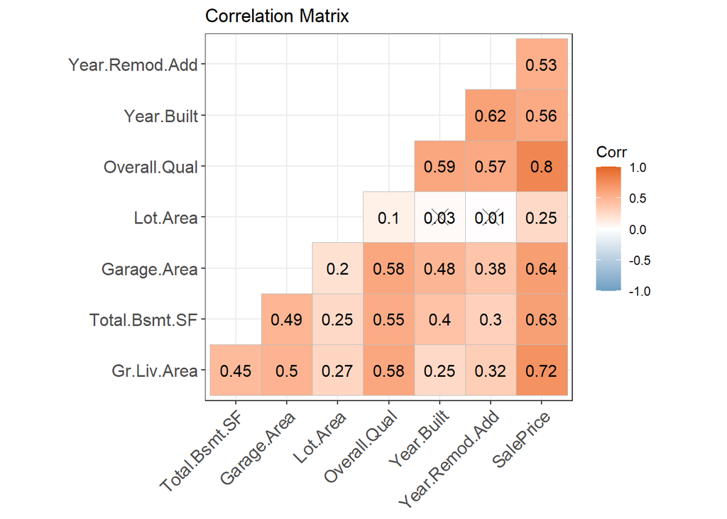

```r
plot_correlation_matrix(train)
```

Some of the variables could be highly correlated:

- Year.Built x Year.Remod.Add
- Overall.Qual x Year.Built
- Garage.Area x Overall.Qual
- Gr.Liv.Area x Overall.Qual
- Overall.Qual x Year.Remod.Add
- Total.Bsmt.SF x Overall.Qual

Checking with the **Variance Inflation Factors**

```r
vif_reg <- lm(SalePrice ~ Year.Built + Year.Remod.Add + Overall.Qual + Garage.Area + Gr.Liv.Area + Total.Bsmt.SF , train)
vif(vif_reg)
```

```
##     Year.Built Year.Remod.Add   Overall.Qual    Garage.Area    Gr.Liv.Area
##       2.076162       1.820995       2.665803       1.767054       1.729126
##  Total.Bsmt.SF
##       1.592197
```

There is no value between 5 to 10 therefore we can exlcude multicollinearity between those variables

## One-hot encoding

```r
train$Neighborhood <- as_factor(train$Neighborhood)
train$House.Style <- as_factor(train$House.Style)
dummyVars(~ ., sep = ".", data = train, fullRank = TRUE)
```

```
## Dummy Variable Object
##
## Formula: ~.
## 10 variables, 2 factors
## Variables and levels will be separated by '.'
## A full rank encoding is used
```

```r
train <- as_tibble(predict(dummyVars(~ ., sep = ".", data = train, fullRank = TRUE), newdata = train))
```

```r
modelFull <- lm(SalePrice ~ . , train)
```

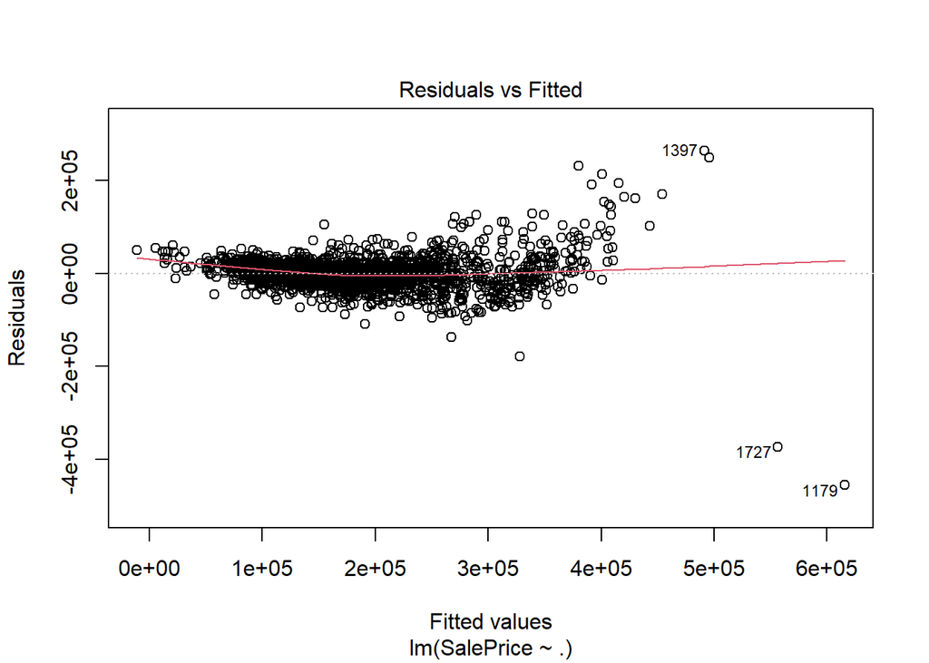

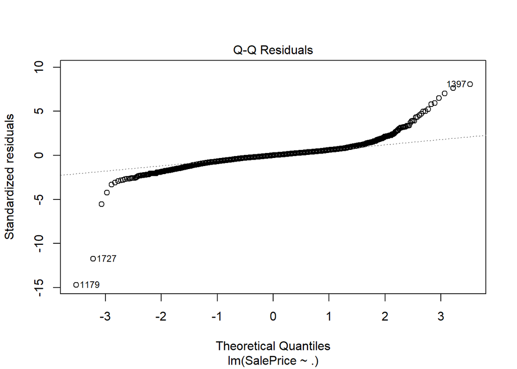

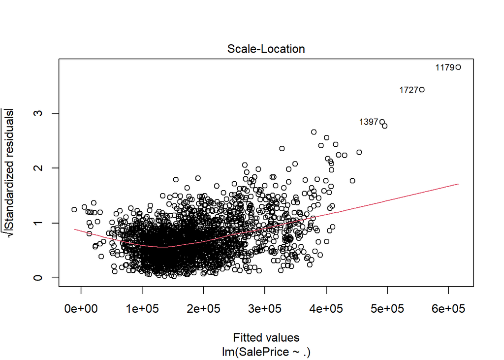

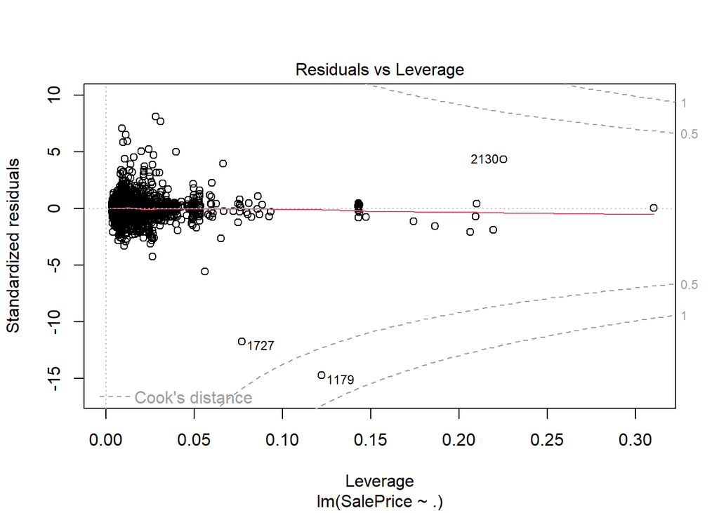

```r
plot(modelFull)
```

```r
print(train[c(1179, 1727, 2130),])
```

```
## # A tibble: 3 × 42
##   Gr.Liv.Area Total.Bsmt.SF Garage.Area Lot.Area Overall.Qual Year.Built
##         <dbl>         <dbl>       <dbl>    <dbl>        <dbl>      <dbl>
## 1        5642          6110        1418    63887           10       2008
## 2        5095          5095        1154    39290           10       2008
## 3        3608          1107         840    22950           10       1892
## # ℹ 36 more variables: Year.Remod.Add <dbl>, Neighborhood.Gilbert <dbl>,
## #   Neighborhood.StoneBr <dbl>, Neighborhood.NWAmes <dbl>,
## #   Neighborhood.Somerst <dbl>, Neighborhood.BrDale <dbl>,
## #   Neighborhood.NPkVill <dbl>, Neighborhood.NridgHt <dbl>,
## #   Neighborhood.Blmngtn <dbl>, Neighborhood.NoRidge <dbl>,
## #   Neighborhood.SawyerW <dbl>, Neighborhood.Sawyer <dbl>,
## #   Neighborhood.Greens <dbl>, Neighborhood.BrkSide <dbl>, …
```

```r
summary(modelFull)
```

```
##
## Call:
## lm(formula = SalePrice ~ ., data = train)
##
## Residuals:
##     Min      1Q  Median      3Q     Max
## -455606  -13617     377   12741  263536
##
## Coefficients:
##                        Estimate Std. Error t value Pr(>|t|)
## (Intercept)          -1.094e+06  1.244e+05  -8.795  < 2e-16 ***
## Gr.Liv.Area           5.404e+01  2.567e+00  21.051  < 2e-16 ***
## Total.Bsmt.SF         1.615e+01  2.561e+00   6.305 3.45e-10 ***
## Garage.Area           3.298e+01  4.448e+00   7.416 1.69e-13 ***
## Lot.Area              6.024e-01  9.362e-02   6.434 1.50e-10 ***
## Overall.Qual          1.671e+04  8.834e+02  18.913  < 2e-16 ***
## Year.Built            2.569e+02  5.449e+01   4.715 2.56e-06 ***
## Year.Remod.Add        2.751e+02  4.713e+01   5.837 6.05e-09 ***
## Neighborhood.Gilbert -4.514e+03  4.176e+03  -1.081 0.279801
## Neighborhood.StoneBr  6.906e+04  6.067e+03  11.383  < 2e-16 ***
## Neighborhood.NWAmes  -7.289e+03  3.807e+03  -1.915 0.055664 .
## Neighborhood.Somerst  8.658e+03  4.307e+03   2.010 0.044539 *
## Neighborhood.BrDale  -1.497e+04  7.097e+03  -2.109 0.035083 *
## Neighborhood.NPkVill -1.327e+04  7.586e+03  -1.749 0.080370 .
## Neighborhood.NridgHt  5.415e+04  4.446e+03  12.180  < 2e-16 ***
## Neighborhood.Blmngtn -1.160e+04  8.203e+03  -1.414 0.157371
## Neighborhood.NoRidge  5.415e+04  5.425e+03   9.982  < 2e-16 ***
## Neighborhood.SawyerW -7.823e+03  4.155e+03  -1.883 0.059835 .
## Neighborhood.Sawyer  -3.174e+02  3.470e+03  -0.091 0.927136
## Neighborhood.Greens  -1.408e+03  1.284e+04  -0.110 0.912704
## Neighborhood.BrkSide  8.831e+03  4.532e+03   1.949 0.051437 .
## Neighborhood.OldTown -5.176e+03  3.713e+03  -1.394 0.163461
## Neighborhood.IDOTRR  -2.034e+03  4.592e+03  -0.443 0.657903
## Neighborhood.ClearCr  1.235e+04  6.010e+03   2.055 0.040001 *
## Neighborhood.SWISU   -5.159e+03  6.071e+03  -0.850 0.395591
## Neighborhood.Edwards -4.579e+03  3.247e+03  -1.410 0.158594
## Neighborhood.CollgCr -6.780e+02  3.616e+03  -0.188 0.851272
## Neighborhood.Crawfor  2.842e+04  4.271e+03   6.654 3.56e-11 ***
## Neighborhood.Blueste -1.639e+04  1.280e+04  -1.280 0.200648
## Neighborhood.Mitchel -3.174e+03  4.190e+03  -0.758 0.448742
## Neighborhood.Timber   1.384e+04  5.286e+03   2.619 0.008883 **
## Neighborhood.MeadowV -5.521e+03  6.578e+03  -0.839 0.401328
## Neighborhood.Veenker  1.155e+04  7.614e+03   1.517 0.129446
## Neighborhood.GrnHill  1.233e+05  3.317e+04   3.717 0.000207 ***
## Neighborhood.Landmrk -1.947e+04  3.318e+04  -0.587 0.557374
## House.Style.2Story   -1.008e+04  2.592e+03  -3.888 0.000104 ***
## House.Style.1.5Fin   -1.081e+04  2.878e+03  -3.756 0.000177 ***
## House.Style.SFoyer    6.577e+03  4.261e+03   1.544 0.122817
## House.Style.SLvl     -2.124e+03  3.554e+03  -0.598 0.550167
## House.Style.2.5Unf   -2.464e+04  7.745e+03  -3.182 0.001482 **
## House.Style.1.5Unf   -3.958e+03  9.201e+03  -0.430 0.667100
## House.Style.2.5Fin   -7.244e+03  1.580e+04  -0.459 0.646544
## ---
## Signif. codes:  0 '***' 0.001 '**' 0.01 '*' 0.05 '.' 0.1 ' ' 1
##
## Residual standard error: 33030 on 2301 degrees of freedom
## Multiple R-squared:   0.84,  Adjusted R-squared:  0.8371
## F-statistic: 294.6 on 41 and 2301 DF,  p-value: < 2.2e-16
```

## Confident interval with bonferroni correction

```r
alpha_level = 1 - (0.1/ncol(train))

confInterval <- confint(modelFull, level = alpha_level)
as.data.frame(confint(modelFull, level = alpha_level))
```

```
##                            0.119 %      99.881 %
## (Intercept)          -1.472275e+06 -7.156312e+05
## Gr.Liv.Area           4.623476e+01  6.185121e+01
## Total.Bsmt.SF         8.358202e+00  2.393767e+01
## Garage.Area           1.945481e+01  4.651002e+01
## Lot.Area              3.176277e-01  8.870861e-01
## Overall.Qual          1.402076e+04  1.939418e+04
## Year.Built            9.119167e+01  4.226576e+02
## Year.Remod.Add        1.317650e+02  4.184439e+02
## Neighborhood.Gilbert -1.721391e+04  8.186039e+03
## Neighborhood.StoneBr  5.060799e+04  8.751502e+04
## Neighborhood.NWAmes  -1.886677e+04  4.289602e+03
## Neighborhood.Somerst -4.442193e+03  2.175738e+04
## Neighborhood.BrDale  -3.655018e+04  6.620091e+03
## Neighborhood.NPkVill -3.634493e+04  9.802778e+03
## Neighborhood.NridgHt  4.062797e+04  6.767115e+04
## Neighborhood.Blmngtn -3.655372e+04  1.334726e+04
## Neighborhood.NoRidge  3.765090e+04  7.064888e+04
## Neighborhood.SawyerW -2.045861e+04  4.813103e+03
## Neighborhood.Sawyer  -1.087232e+04  1.023753e+04
## Neighborhood.Greens  -4.046487e+04  3.764896e+04
## Neighborhood.BrkSide -4.951317e+03  2.261386e+04
## Neighborhood.OldTown -1.647086e+04  6.117899e+03
## Neighborhood.IDOTRR  -1.600100e+04  1.193345e+04
## Neighborhood.ClearCr -5.929435e+03  3.063054e+04
## Neighborhood.SWISU   -2.362359e+04  1.330654e+04
## Neighborhood.Edwards -1.445490e+04  5.296487e+03
## Neighborhood.CollgCr -1.167570e+04  1.031961e+04
## Neighborhood.Crawfor  1.542729e+04  4.140688e+04
## Neighborhood.Blueste -5.531754e+04  2.254646e+04
## Neighborhood.Mitchel -1.591709e+04  9.568485e+03
## Neighborhood.Timber  -2.234511e+03  2.992151e+04
## Neighborhood.MeadowV -2.552765e+04  1.448469e+04
## Neighborhood.Veenker -1.160911e+04  3.470879e+04
## Neighborhood.GrnHill  2.239099e+04  2.241416e+05
## Neighborhood.Landmrk -1.203991e+05  8.145285e+04
## House.Style.2Story   -1.795914e+04 -2.194198e+03
## House.Style.1.5Fin   -1.956680e+04 -2.057744e+03
## House.Style.SFoyer   -6.381867e+03  1.953582e+04
## House.Style.SLvl     -1.293327e+04  8.685514e+03
## House.Style.2.5Unf   -4.819867e+04 -1.088453e+03
## House.Style.1.5Unf   -3.194129e+04  2.402530e+04
## House.Style.2.5Fin   -5.528602e+04  4.079736e+04
```

## Hypothesis testing

Testing variables that are outside of the confidence interval

Check whether the coefficients outside the confidence interval

```r
coeffNotSignificantList <-  c()
for (i in 1:length(modelFull$coefficients)){

  # If Lower < 0 AND Upper > 0, the effect is not significant
  if (confInterval[i, 1] < 0 && confInterval[i, 2] > 0) {

    coeffNotSignificantList <- c(coeffNotSignificantList, names(modelFull$coefficients)[i])
  }
}
print(coeffNotSignificantList)
```

```
##  [1] "Neighborhood.Gilbert" "Neighborhood.NWAmes"  "Neighborhood.Somerst"
##  [4] "Neighborhood.BrDale"  "Neighborhood.NPkVill" "Neighborhood.Blmngtn"
##  [7] "Neighborhood.SawyerW" "Neighborhood.Sawyer"  "Neighborhood.Greens"
## [10] "Neighborhood.BrkSide" "Neighborhood.OldTown" "Neighborhood.IDOTRR"
## [13] "Neighborhood.ClearCr" "Neighborhood.SWISU"   "Neighborhood.Edwards"
## [16] "Neighborhood.CollgCr" "Neighborhood.Blueste" "Neighborhood.Mitchel"
## [19] "Neighborhood.Timber"  "Neighborhood.MeadowV" "Neighborhood.Veenker"
## [22] "Neighborhood.Landmrk" "House.Style.SFoyer"   "House.Style.SLvl"
## [25] "House.Style.1.5Unf"   "House.Style.2.5Fin"
```

```r
print(length(coeffNotSignificantList))
```

```
## [1] 26
```

Test if the 26 coefficients are zero

```r
linearHypothesis(modelFull, hypothesis.matrix = coeffNotSignificantList)
```

```
##
## Linear hypothesis test:
## Neighborhood.Gilbert = 0
## Neighborhood.NWAmes = 0
## Neighborhood.Somerst = 0
## Neighborhood.BrDale = 0
## Neighborhood.NPkVill = 0
## Neighborhood.Blmngtn = 0
## Neighborhood.SawyerW = 0
## Neighborhood.Sawyer = 0
## Neighborhood.Greens = 0
## Neighborhood.BrkSide = 0
## Neighborhood.OldTown = 0
## Neighborhood.IDOTRR = 0
## Neighborhood.ClearCr = 0
## Neighborhood.SWISU = 0
## Neighborhood.Edwards = 0
## Neighborhood.CollgCr = 0
## Neighborhood.Blueste = 0
## Neighborhood.Mitchel = 0
## Neighborhood.Timber = 0
## Neighborhood.MeadowV = 0
## Neighborhood.Veenker = 0
## Neighborhood.Landmrk = 0
## House.Style.SFoyer = 0
## House.Style.SLvl = 0
## House.Style.1.5Unf = 0
## House.Style.2.5Fin = 0
##
## Model 1: restricted model
## Model 2: SalePrice ~ Gr.Liv.Area + Total.Bsmt.SF + Garage.Area + Lot.Area +
##     Overall.Qual + Year.Built + Year.Remod.Add + Neighborhood.Gilbert +
##     Neighborhood.StoneBr + Neighborhood.NWAmes + Neighborhood.Somerst +
##     Neighborhood.BrDale + Neighborhood.NPkVill + Neighborhood.NridgHt +
##     Neighborhood.Blmngtn + Neighborhood.NoRidge + Neighborhood.SawyerW +
##     Neighborhood.Sawyer + Neighborhood.Greens + Neighborhood.BrkSide +
##     Neighborhood.OldTown + Neighborhood.IDOTRR + Neighborhood.ClearCr +
##     Neighborhood.SWISU + Neighborhood.Edwards + Neighborhood.CollgCr +
##     Neighborhood.Crawfor + Neighborhood.Blueste + Neighborhood.Mitchel +
##     Neighborhood.Timber + Neighborhood.MeadowV + Neighborhood.Veenker +
##     Neighborhood.GrnHill + Neighborhood.Landmrk + House.Style.2Story +
##     House.Style.1.5Fin + House.Style.SFoyer + House.Style.SLvl +
##     House.Style.2.5Unf + House.Style.1.5Unf + House.Style.2.5Fin
##
##   Res.Df       RSS Df  Sum of Sq      F    Pr(>F)
## 1   2327 2.578e+12
## 2   2301 2.510e+12 26 6.8022e+10 2.3984 9.415e-05 ***
## ---
## Signif. codes:  0 '***' 0.001 '**' 0.01 '*' 0.05 '.' 0.1 ' ' 1
```

The variables can’t be eliminated because the restricted model increases RSS in a significant way

## Alternative model based on different categorization

Test different range prices for the neighborhoods

```r
train2 <- data[-index,]
# find the median value for each neighborhood
neigh_summary <- train2 %>%
  group_by(Neighborhood) %>%
  summarise(MedianPrice = median(SalePrice, na.rm = TRUE)) %>%
  arrange(MedianPrice)

# Create a new variable based on the median price
train2 <- train2 %>%
  mutate(Neighborhood_Price_Range = case_when(
    Neighborhood %in% neigh_summary$Neighborhood[1:7] ~ "Low",
    Neighborhood %in% neigh_summary$Neighborhood[8:14] ~ "Medium",
    Neighborhood %in% neigh_summary$Neighborhood[15:24] ~ "High",
    TRUE ~ "Very_High"
  ))
```

Check median prices for different house styles

```r
house_style_summary <- train2 %>%
  group_by(House.Style) %>%
  summarise(MedianPrice = median(SalePrice, na.rm = TRUE)) %>%
  arrange(MedianPrice)
print(house_style_summary)
```

```
## # A tibble: 8 × 2
##   House.Style MedianPrice
##   <chr>             <dbl>
## 1 1.5Unf           107500
## 2 1.5Fin           129875
## 3 SFoyer           142500
## 4 1Story           153750
## 5 2.5Unf           160950
## 6 SLvl             165000
## 7 2Story           190525
## 8 2.5Fin           191000
```

```r
train2 <- train2 %>%
  mutate(House.Style = case_when(
    House.Style %in% house_style_summary$House.Style[1:2] ~ "1.5",
    House.Style %in% house_style_summary$House.Style[4] ~ "1Story",
    House.Style %in% house_style_summary$House.Style[3] ~ "SFoyer",
    House.Style %in% house_style_summary$House.Style[5:6] ~ "Split",
    TRUE ~ "2Story"
  ))
```

**ONE-HOT ENCODING**

```r
train2$Neighborhood_Price_Range <- as_factor(train2$Neighborhood_Price_Range)
train2$House.Style <- as_factor(train2$House.Style)
train2 <- select(train2, -Neighborhood)
train2 <- as_tibble(predict(dummyVars(~ ., sep = ".", data = train2, fullRank = TRUE), newdata = train2))
```

```r
modelAlt <- lm(SalePrice ~ . , train2)
```

```r
alpha_level_alt = 1 - (0.1/ncol(train2))

confInterval <- confint(modelAlt, level = alpha_level_alt)
as.data.frame(confint(modelAlt, level = alpha_level_alt))
```

```
##                                          0.333 %      99.667 %
## (Intercept)                        -1.085342e+06 -5.446712e+05
## Gr.Liv.Area                         4.674499e+01  5.983261e+01
## Total.Bsmt.SF                       1.039342e+01  2.431627e+01
## Garage.Area                         2.046920e+01  4.408744e+01
## Lot.Area                            3.962470e-01  8.857735e-01
## Overall.Qual                        1.479565e+04  1.939575e+04
## Year.Built                          3.834558e+01  2.559933e+02
## Year.Remod.Add                      1.154546e+02  3.662296e+02
## House.Style.2Story                 -1.853517e+04 -5.331765e+03
## House.Style.1.5                    -1.595192e+04 -1.036676e+03
## House.Style.SFoyer                 -4.231537e+03  1.887411e+04
## House.Style.Split                  -1.504056e+04  3.106891e+03
## Neighborhood_Price_Range.High       4.058815e+03  1.576063e+04
## Neighborhood_Price_Range.Very_High  5.472280e+04  7.279134e+04
## Neighborhood_Price_Range.Low       -1.025181e+04  1.553512e+03
```

```r
coeffNotSignificantListAlt <-  c()
for (i in 1:length(modelAlt$coefficients)){
  # If Lower < 0 AND Upper > 0, the effect is not significant
  if (confInterval[i, 1] < 0 && confInterval[i, 2] > 0) {

    coeffNotSignificantListAlt <- c(coeffNotSignificantListAlt, names(modelAlt$coefficients)[i])
  }
}
print(coeffNotSignificantListAlt)
```

```
## [1] "House.Style.SFoyer"           "House.Style.Split"
## [3] "Neighborhood_Price_Range.Low"
```

```r
print(length(coeffNotSignificantListAlt))
```

```
## [1] 3
```

**Test if nieghborhood_Price_Range.Low is zero**

```r
linearHypothesis(modelAlt, "Neighborhood_Price_Range.Low = 0")
```

```
##
## Linear hypothesis test:
## Neighborhood_Price_Range.Low = 0
##
## Model 1: restricted model
## Model 2: SalePrice ~ Gr.Liv.Area + Total.Bsmt.SF + Garage.Area + Lot.Area +
##     Overall.Qual + Year.Built + Year.Remod.Add + House.Style.2Story +
##     House.Style.1.5 + House.Style.SFoyer + House.Style.Split +
##     Neighborhood_Price_Range.High + Neighborhood_Price_Range.Very_High +
##     Neighborhood_Price_Range.Low
##
##   Res.Df        RSS Df  Sum of Sq      F  Pr(>F)
## 1   2329 2.6332e+12
## 2   2328 2.6286e+12  1 4520189390 4.0032 0.04553 *
## ---
## Signif. codes:  0 '***' 0.001 '**' 0.01 '*' 0.05 '.' 0.1 ' ' 1
```

Reject the hypothesis

**Test if House.Style.Sfoyer and House.Style.Split are equal**

```r
linearHypothesis(modelAlt, "House.Style.SFoyer = House.Style.Split")
```

```
##
## Linear hypothesis test:
## House.Style.SFoyer - House.Style.Split = 0
##
## Model 1: restricted model
## Model 2: SalePrice ~ Gr.Liv.Area + Total.Bsmt.SF + Garage.Area + Lot.Area +
##     Overall.Qual + Year.Built + Year.Remod.Add + House.Style.2Story +
##     House.Style.1.5 + House.Style.SFoyer + House.Style.Split +
##     Neighborhood_Price_Range.High + Neighborhood_Price_Range.Very_High +
##     Neighborhood_Price_Range.Low
##
##   Res.Df        RSS Df Sum of Sq      F  Pr(>F)
## 1   2329 2.6361e+12
## 2   2328 2.6286e+12  1 7.421e+09 6.5723 0.01042 *
## ---
## Signif. codes:  0 '***' 0.001 '**' 0.01 '*' 0.05 '.' 0.1 ' ' 1
```

Hypothesis rejected

Overall RSS of alternative model is worse than full model in the training dataset

But the increase in RSS is bearable considering the reduction in the number of parameters (from 42 to 15)

# Model Evaluation

## TYPE 1

```r
#R², adj R² and Cp for each possible model
each_model <- ols_step_all_possible(modelAlt)
# each_model #a lot of informations!
```

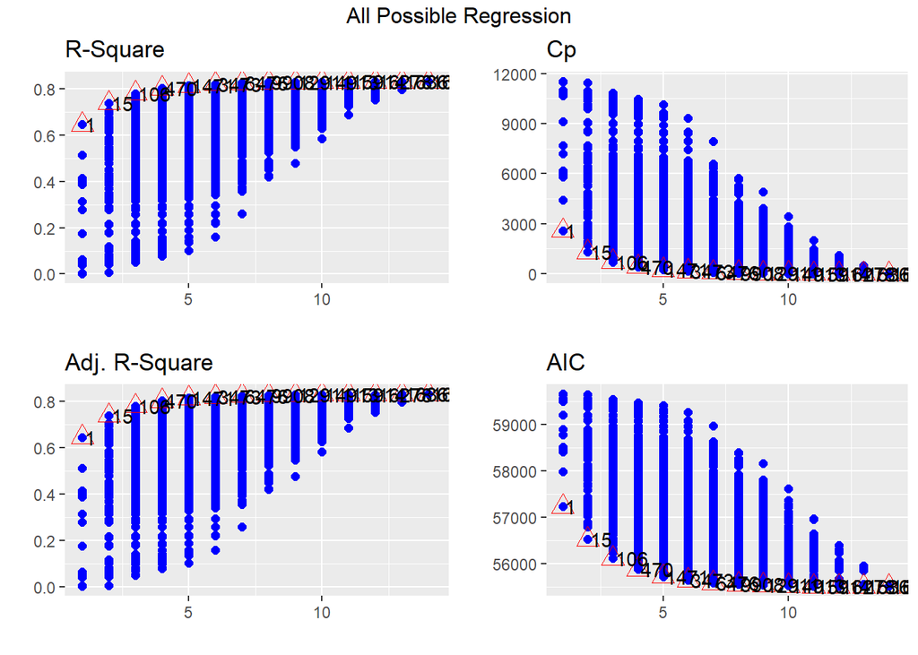

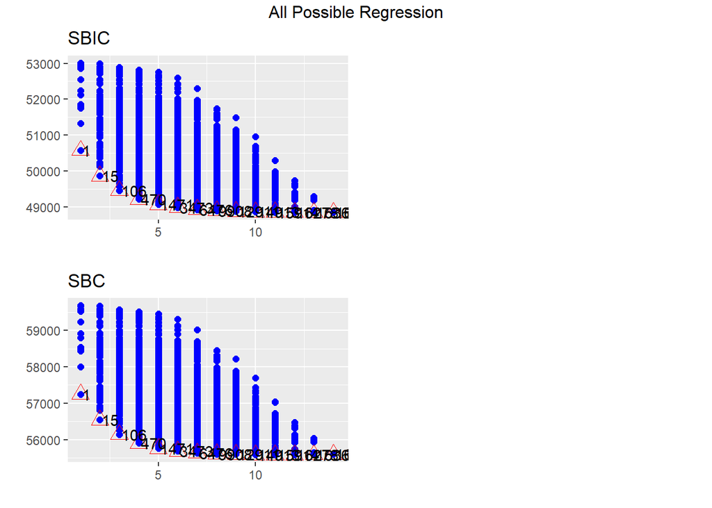

```r
#plot the criteria for the number of parameters and displays the number of the best model
plot(each_model)
```

```r
#R², adj R² and Cp for the best subset of variables for each number of parameters
best_subset <- ols_step_best_subset(modelAlt)
```

```r
# look at the best chosen models
best_subset
```

```
##                                                                                                                          Best Subsets Regression
## --------------------------------------------------------------------------------------------------------------------------------------------------------------------------------------------------------------------------------------------------------------------------
## Model Index    Predictors
## --------------------------------------------------------------------------------------------------------------------------------------------------------------------------------------------------------------------------------------------------------------------------
##      1         Overall.Qual
##      2         Gr.Liv.Area Overall.Qual
##      3         Gr.Liv.Area Overall.Qual Neighborhood_Price_Range.Very_High
##      4         Gr.Liv.Area Total.Bsmt.SF Overall.Qual Neighborhood_Price_Range.Very_High
##      5         Gr.Liv.Area Total.Bsmt.SF Overall.Qual Year.Built Neighborhood_Price_Range.Very_High
##      6         Gr.Liv.Area Total.Bsmt.SF Lot.Area Overall.Qual Year.Built Neighborhood_Price_Range.Very_High
##      7         Gr.Liv.Area Total.Bsmt.SF Garage.Area Lot.Area Overall.Qual Year.Built Neighborhood_Price_Range.Very_High
##      8         Gr.Liv.Area Total.Bsmt.SF Garage.Area Lot.Area Overall.Qual Year.Built Year.Remod.Add Neighborhood_Price_Range.Very_High
##      9         Gr.Liv.Area Total.Bsmt.SF Garage.Area Lot.Area Overall.Qual Year.Built Year.Remod.Add Neighborhood_Price_Range.High Neighborhood_Price_Range.Very_High
##     10         Gr.Liv.Area Total.Bsmt.SF Garage.Area Lot.Area Overall.Qual Year.Built Year.Remod.Add House.Style.2Story Neighborhood_Price_Range.High Neighborhood_Price_Range.Very_High
##     11         Gr.Liv.Area Total.Bsmt.SF Garage.Area Lot.Area Overall.Qual Year.Built Year.Remod.Add House.Style.2Story House.Style.1.5 Neighborhood_Price_Range.High Neighborhood_Price_Range.Very_High
##     12         Gr.Liv.Area Total.Bsmt.SF Garage.Area Lot.Area Overall.Qual Year.Built Year.Remod.Add House.Style.2Story House.Style.1.5 Neighborhood_Price_Range.High Neighborhood_Price_Range.Very_High Neighborhood_Price_Range.Low
##     13         Gr.Liv.Area Total.Bsmt.SF Garage.Area Lot.Area Overall.Qual Year.Built Year.Remod.Add House.Style.2Story House.Style.1.5 House.Style.Split Neighborhood_Price_Range.High Neighborhood_Price_Range.Very_High Neighborhood_Price_Range.Low
##     14         Gr.Liv.Area Total.Bsmt.SF Garage.Area Lot.Area Overall.Qual Year.Built Year.Remod.Add House.Style.2Story House.Style.1.5 House.Style.SFoyer House.Style.Split Neighborhood_Price_Range.High Neighborhood_Price_Range.Very_High Neighborhood_Price_Range.Low
## --------------------------------------------------------------------------------------------------------------------------------------------------------------------------------------------------------------------------------------------------------------------------
##
##                                                                  Subsets Regression Summary
## -------------------------------------------------------------------------------------------------------------------------------------------------------------
##                        Adj.        Pred
## Model    R-Square    R-Square    R-Square      C(p)          AIC           SBIC          SBC            MSEP              FPE              HSP          APC
## -------------------------------------------------------------------------------------------------------------------------------------------------------------
##   1        0.6457      0.6455      0.6446    2583.4688    57233.7191    50581.9278    57250.9966    5.562899e+12    2376289984.5110    1014642.4350    0.3549
##   2        0.7389      0.7387      0.7367    1290.5434    56520.5077    49868.9863    56543.5445    4.101252e+12    1752668577.2980     748365.6747    0.2618
##   3        0.7806      0.7803      0.7784     712.7982    56114.5065    49463.4036    56143.3025    3.447274e+12    1473818867.3113     629301.5538    0.2201
##   4        0.8022      0.8018      0.7966     415.4268    55874.2619    49223.5973    55908.8171    3.109994e+12    1330187263.7752     567973.7558    0.1987
##   5        0.8150      0.8146      0.8094     239.6872    55719.6197    49069.3952    55759.9341    2.910117e+12    1245227131.8569     531697.9773    0.1860
##   6        0.8211      0.8206      0.8149     156.6369    55642.7910    48992.8351    55688.8645    2.815042e+12    1205057395.5860     514547.2646    0.1800
```

[output cut: 16 more lines]

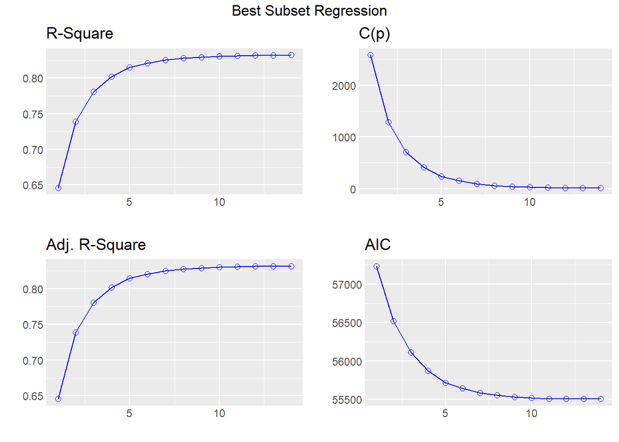

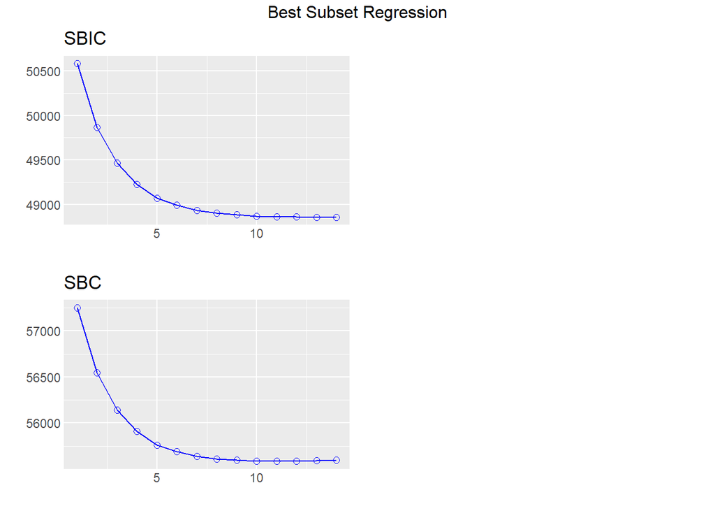

```r
# plot the criteria for the number of parameters and displays the number of the best model
plot(best_subset)
```

## Type 2

```r
forward <- ols_step_forward_adj_r2(modelAlt)
#details = TRUE: print the regression result at each step
#progress = TRUE: display variable selection progress
```

```r
forward
```

```
##
##
##                                             Stepwise Summary
## -------------------------------------------------------------------------------------------------------
## Step    Variable                                 AIC          SBC         SBIC         R2       Adj. R2
## -------------------------------------------------------------------------------------------------------
##  0      Base Model                            59662.675    59674.194    53010.485    0.00000    0.00000
##  1      Overall.Qual                          57233.719    57250.997    50581.928    0.64567    0.64552
##  2      Gr.Liv.Area                           56520.508    56543.544    49868.986    0.73889    0.73866
##  3      Neighborhood_Price_Range.Very_High    56114.507    56143.302    49463.404    0.78062    0.78033
##  4      Total.Bsmt.SF                         55874.262    55908.817    49223.597    0.80216    0.80183
##  5      Year.Built                            55719.620    55759.934    49069.395    0.81496    0.81456
##  6      Lot.Area                              55642.791    55688.865    48992.835    0.82108    0.82062
##  7      Garage.Area                           55584.895    55636.728    48935.219    0.82560    0.82507
##  8      Year.Remod.Add                        55552.242    55609.834    48902.761    0.82816    0.82757
##  9      Neighborhood_Price_Range.High         55533.811    55597.162    48884.465    0.82965    0.82899
##  10     House.Style.2Story                    55518.839    55587.949    48869.632    0.83088    0.83015
##  11     House.Style.1.5                       55510.102    55584.971    48860.999    0.83165    0.83086
##  12     Neighborhood_Price_Range.Low          55508.029    55588.658    48858.975    0.83194    0.83108
##  13     House.Style.Split                     55506.258    55592.645    48857.256    0.83221    0.83128
##  14     House.Style.SFoyer                    55505.279    55597.426    48856.326    0.83243    0.83142
## -------------------------------------------------------------------------------------------------------
##
## Final Model Output
## ------------------
##
##                               Model Summary
## --------------------------------------------------------------------------
## R                           0.912       RMSE                    33494.924
## R-Squared                   0.832       MSE                1121909965.014
## Adj. R-Squared              0.831       Coef. Var                  18.492
## Pred R-Squared              0.825       AIC                     55505.279
## MAE                     21092.979       SBC                     55597.426
## --------------------------------------------------------------------------
##  RMSE: Root Mean Square Error
##  MSE: Mean Square Error
##  MAE: Mean Absolute Error
##  AIC: Akaike Information Criteria
##  SBC: Schwarz Bayesian Criteria
##
```

[output cut: 15 more lines]

```
##                       Overall.Qual      17095.695       847.011        0.298    20.184    0.000       15434.721      18756.670
##                        Gr.Liv.Area         53.289         2.410        0.332    22.113    0.000          48.563         58.014
## Neighborhood_Price_Range.Very_High      63757.069      3326.938        0.237    19.164    0.000       57232.998      70281.139
##                      Total.Bsmt.SF         17.355         2.564        0.095     6.770    0.000          12.328         22.382
##                         Year.Built        147.169        40.075        0.055     3.672    0.000          68.583        225.756
##                           Lot.Area          0.641         0.090        0.066     7.112    0.000           0.464          0.818
##                        Garage.Area         32.278         4.349        0.085     7.422    0.000          23.750         40.806
##                     Year.Remod.Add        240.842        46.175        0.062     5.216    0.000         150.294        331.390
##      Neighborhood_Price_Range.High       9909.720      2154.641        0.058     4.599    0.000        5684.505      14134.935
##                 House.Style.2Story     -11933.470      2431.128       -0.067    -4.909    0.000      -16700.873      -7166.067
##                    House.Style.1.5      -8494.298      2746.327       -0.033    -3.093    0.002      -13879.799      -3108.797
##       Neighborhood_Price_Range.Low      -4349.150      2173.701       -0.023    -2.001    0.046       -8611.741        -86.559
##                  House.Style.Split      -5966.836      3341.469       -0.017    -1.786    0.074      -12519.402        585.731
##                 House.Style.SFoyer       7321.286      4254.416        0.015     1.721    0.085       -1021.554      15664.125
## -------------------------------------------------------------------------------------------------------------------------------
```

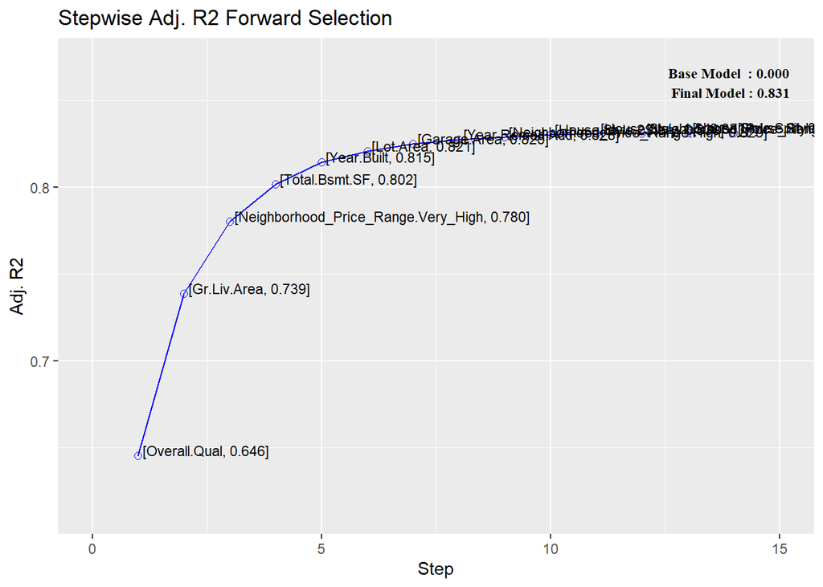

```r
plot(forward)
```

```r
backward <- ols_step_backward_p(modelAlt)
```

```r
backward
```

```
## [1] "No variables have been removed from the model."
```

## Type 3

### Full Model

Using Lasso model for feature selection

```r
matrixFull <- as.matrix(train %>% select(-SalePrice))
responseFull <- train$SalePrice
modelLassoFull <- cv.glmnet(matrixFull, responseFull, alpha = 1, nfolds =5)
modelLassoFull
```

```
##
## Call:  cv.glmnet(x = matrixFull, y = responseFull, nfolds = 5, alpha = 1)
##
## Measure: Mean-Squared Error
##
##     Lambda Index   Measure        SE Nonzero
## min    298    59 1.152e+09 163497619      35
## 1se   4859    29 1.300e+09 177188088      10
```

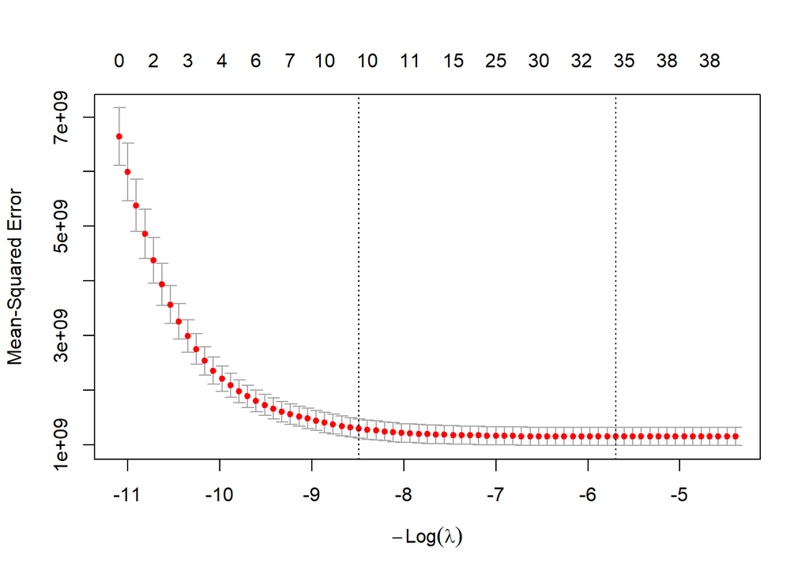

```r
plot(modelLassoFull)
```

```r
bestLambdaFull <- modelLassoFull$lambda.min
bestLambdaFull
```

```
## [1] 298.1608
```

```r
lassoCoefficientsFull <- predict(modelLassoFull, s = bestLambdaFull, type = "coefficients")
lassoCoefficientsFull
```

```
## 42 x 1 sparse Matrix of class "dgCMatrix"
##                         s=298.1608
## (Intercept)          -1.072362e+06
## Gr.Liv.Area           5.167245e+01
## Total.Bsmt.SF         1.823649e+01
## Garage.Area           3.389638e+01
## Lot.Area              5.983498e-01
## Overall.Qual          1.682207e+04
## Year.Built            2.547043e+02
## Year.Remod.Add        2.656145e+02
## Neighborhood.Gilbert -2.693550e+03
## Neighborhood.StoneBr  6.782470e+04
## Neighborhood.NWAmes  -4.994324e+03
## Neighborhood.Somerst  7.982201e+03
## Neighborhood.BrDale  -1.266793e+04
## Neighborhood.NPkVill -1.004844e+04
## Neighborhood.NridgHt  5.363420e+04
## Neighborhood.Blmngtn -7.060290e+03
## Neighborhood.NoRidge  5.317365e+04
## Neighborhood.SawyerW -5.334929e+03
## Neighborhood.Sawyer   .
## Neighborhood.Greens   .
## Neighborhood.BrkSide  7.099555e+03
## Neighborhood.OldTown -3.909439e+03
## Neighborhood.IDOTRR  -2.283907e+02
## Neighborhood.ClearCr  1.081391e+04
## Neighborhood.SWISU   -2.741776e+03
## Neighborhood.Edwards -2.366057e+03
## Neighborhood.CollgCr  .
## Neighborhood.Crawfor  2.736282e+04
## Neighborhood.Blueste -1.115764e+04
## Neighborhood.Mitchel -3.488497e+02
## Neighborhood.Timber   1.289444e+04
## Neighborhood.MeadowV -2.220095e+03
## Neighborhood.Veenker  9.479346e+03
## Neighborhood.GrnHill  1.100486e+05
## Neighborhood.Landmrk -5.164561e+03
## House.Style.2Story   -7.511396e+03
## House.Style.1.5Fin   -8.286390e+03
## House.Style.SFoyer    4.499916e+03
## House.Style.SLvl      .
## House.Style.2.5Unf   -1.910392e+04
## House.Style.1.5Unf    .
## House.Style.2.5Fin    .
```

### Alternative Model

Using Lasso model

```r
matrix <- as.matrix(train2 %>% select(-SalePrice))
response <- train2$SalePrice
modelLasso <- cv.glmnet(matrix, response, alpha = 1, nfolds =5)

modelLasso
```

```
##
## Call:  cv.glmnet(x = matrix, y = response, nfolds = 5, alpha = 1)
##
## Measure: Mean-Squared Error
##
##     Lambda Index   Measure        SE Nonzero
## min    129    68 1.163e+09 127653130      14
## 1se   6424    26 1.289e+09 125597724       9
```

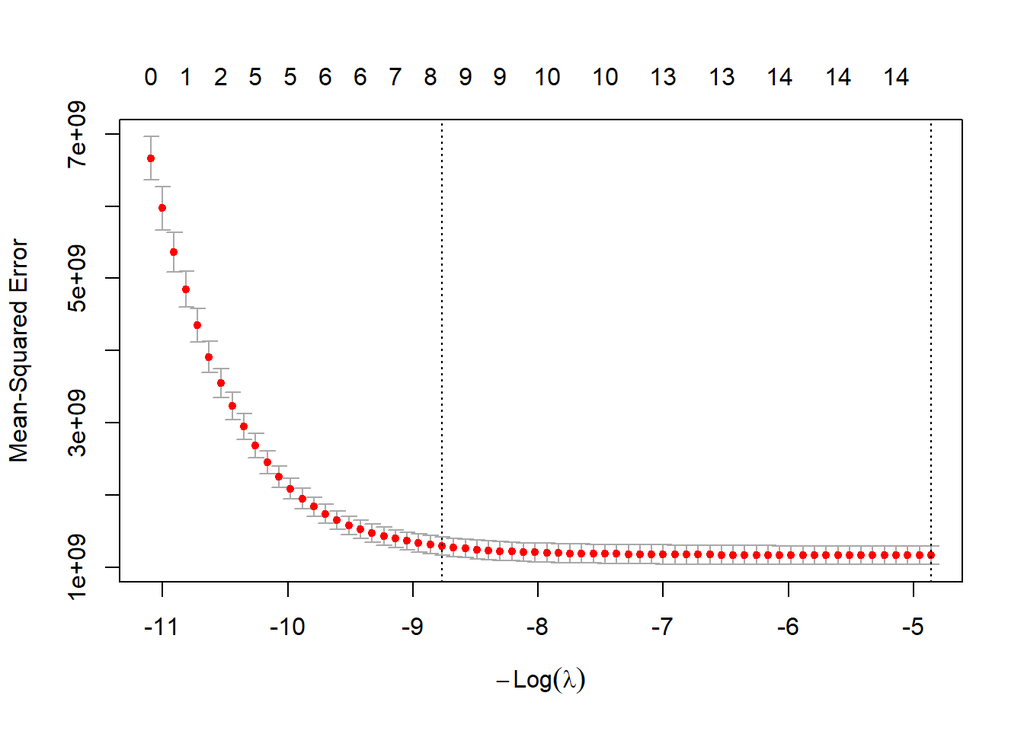

```r
plot(modelLasso)
```

Best lambda

```r
bestLambda <- modelLasso$lambda.min
bestLambda
```

```
## [1] 129.0667
```

```r
lassoCoefficients <- predict(modelLasso, s = bestLambda, type = "coefficients")
lassoCoefficients
```

```
## 15 x 1 sparse Matrix of class "dgCMatrix"
##                                       s=129.0667
## (Intercept)                        -8.173668e+05
## Gr.Liv.Area                         5.232988e+01
## Total.Bsmt.SF                       1.810572e+01
## Garage.Area                         3.240104e+01
## Lot.Area                            6.354339e-01
## Overall.Qual                        1.708804e+04
## Year.Built                          1.493004e+02
## Year.Remod.Add                      2.401307e+02
## House.Style.2Story                 -1.066922e+04
## House.Style.1.5                    -7.516734e+03
## House.Style.SFoyer                  6.579425e+03
## House.Style.Split                  -4.810685e+03
## Neighborhood_Price_Range.High       9.386731e+03
## Neighborhood_Price_Range.Very_High  6.316874e+04
## Neighborhood_Price_Range.Low       -4.450031e+03
```

Based on all the types of model evalutation that I used, No coefficients is equal to zero and even the features with non significant coefficients improve in a significant way the prediciton power of the model. Therefore I will keep all the features in the alternative model.

# Checking for heteroskedasticity

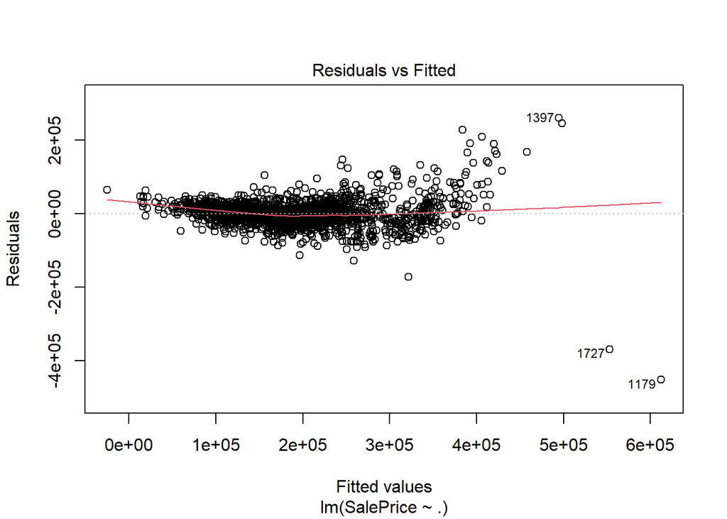

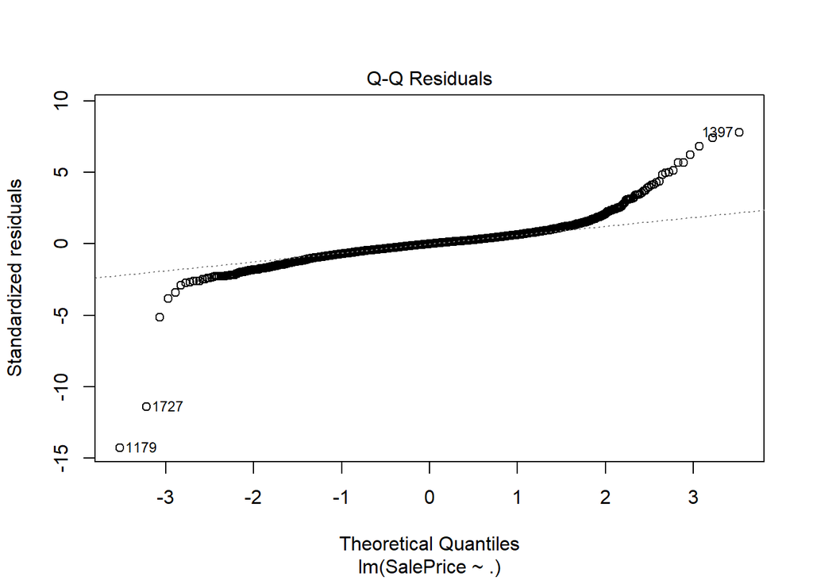

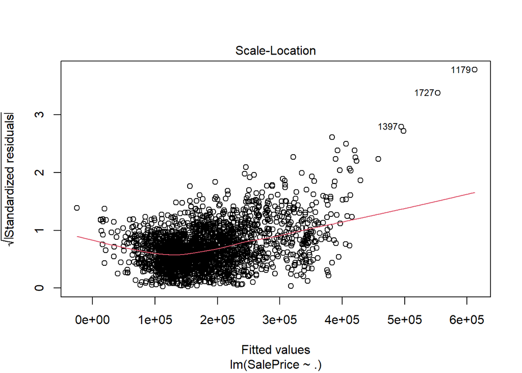

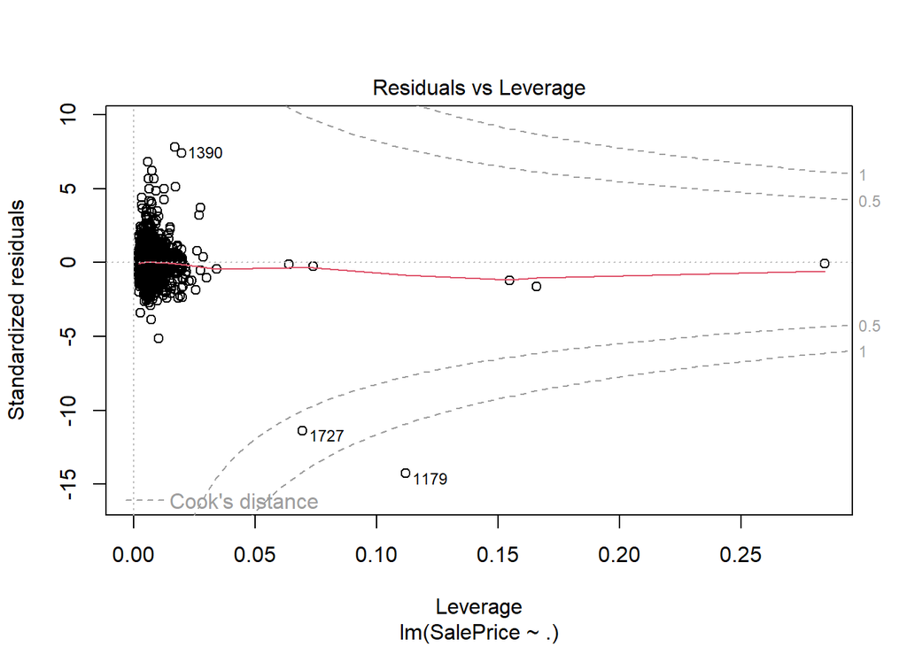

```r
plot(modelAlt)
```

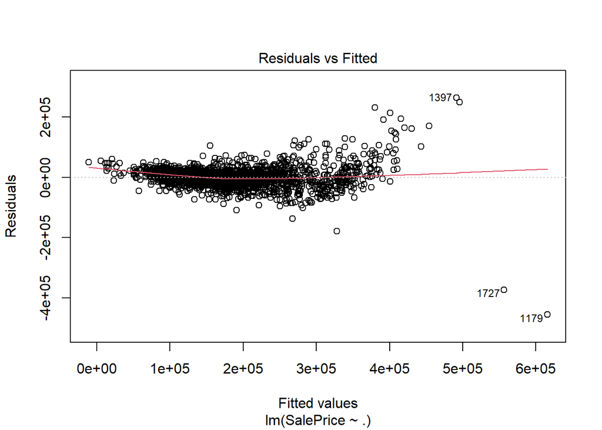

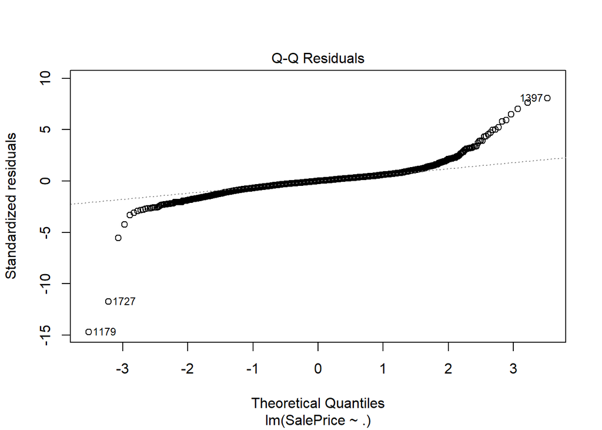

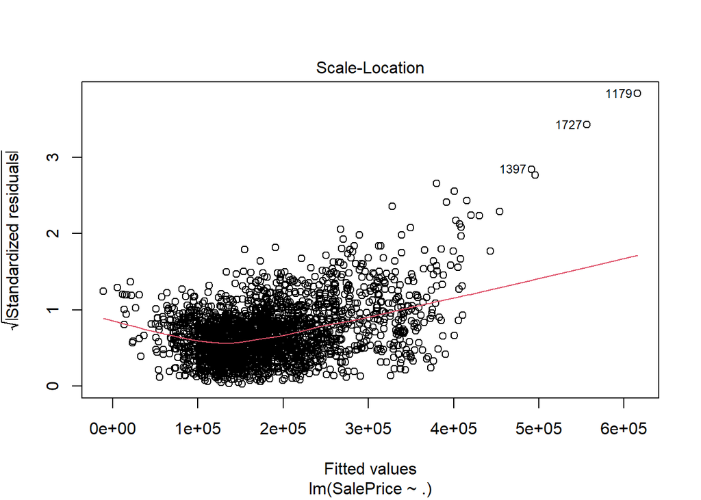

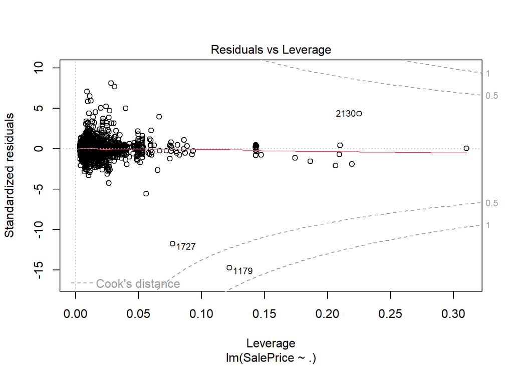

```r
plot(modelFull)
```

It looks like there is a bit of heteroskedasticity in the residuals of both models, especially for high values of SalePrice.

We can check which variables show this behavior